# Activity prediction project

Practical machine learning course.

## Summary

Using devices such as Jawbone Up, Nike FuelBand, and Fitbit it is now possible to collect a large amount of data about personal activity relatively inexpensively. These type of devices are part of the quantified self movement – a group of enthusiasts who take measurements about themselves regularly to improve their health, to find patterns in their behavior, or because they are tech geeks. One thing that people regularly do is quantify how much of a particular activity they do, but they rarely quantify how well they do it. In this project, your goal will be to use data from accelerometers on the belt, forearm, arm, and dumbell of 6 participants. They were asked to perform barbell lifts correctly and incorrectly in 5 different ways. More information is available from the website here: http://groupware.les.inf.puc-rio.br/har (see the section on the Weight Lifting Exercise Dataset).

The goal of the project is to predict the manner in which participants did the exercise. This is the “classe” variable in the training set.

During prediction I reduced number of predictors. Than I tried two meodels. Classification tree with poor results and Random forrest with excelent coeffitients. Prediction made on testing set and result submission confirmed very high accuracy of model and all 20 cases were predicted correctly.

## Data loading

Downloading data to data.frames. Substitution of strings ‘NA’,‘#DIV/0!’ to NA values.

```r
url.train <- "http://d396qusza40orc.cloudfront.net/predmachlearn/pml-training.csv"
url.test <- "http://d396qusza40orc.cloudfront.net/predmachlearn/pml-testing.csv"

ds.train <- read.csv(url(url.train), na.strings=c("NA","#DIV/0!",""))
ds.test <- read.csv(url(url.test), na.strings=c("NA","#DIV/0!",""))
```

## Data processing and feature selection

Library loading

```r
library(caret)
library(rattle)
library(rpart)
library(randomForest)
```

```r
ds.train <- ds.train[,c(-1:-7)]
```

I explored that there were sparsely filled variables. I got rid of those, which had more than 90% NA values.

```r
NA.90.colnames <- sapply(ds.train, function(x) sum(is.na(x)) / length(x) >= .9 )
ds.train <- ds.train[,!NA.90.colnames]
```

Finally I checked up for NZV variables. Found nothing.

```r
nzv <- nearZeroVar(ds.train,saveMetrics=TRUE)
nzv.colnames <- colnames(ds.train) %in% rownames(nzv[nzv$nzv,])
ds.train <- ds.train[, !nzv.colnames,]
```

## Data splitting

Training data set is splitted into two data sets, 70% for model traning and 30% for result testing.

```r
set.seed(1234)

inTraining <- createDataPartition(y=ds.train$classe,p=.7,list=F)

ds.train.train <- ds.train[inTraining,]
ds.train.test <- ds.train[-inTraining,]

dim(ds.train.train)
```

```
## [1] 13737    53
```

```r
dim(ds.train.test)
```

```
## [1] 5885   53
```

## Model selection

### Classification Tree

First I tried classification tree.

```r
mod.dt <- train(classe ~ .,method="rpart",data=ds.train.train)
print(mod.dt$finalModel)
```

```
## n= 13737
##
## node), split, n, loss, yval, (yprob)
##       * denotes terminal node
##
##  1) root 13737 9831 A (0.28 0.19 0.17 0.16 0.18)
##    2) roll_belt< 130.5 12563 8667 A (0.31 0.21 0.19 0.18 0.11)
##      4) pitch_forearm< -33.05 1111   14 A (0.99 0.013 0 0 0) *
##      5) pitch_forearm>=-33.05 11452 8653 A (0.24 0.23 0.21 0.2 0.12)
##       10) magnet_dumbbell_y< 436.5 9625 6886 A (0.28 0.18 0.24 0.19 0.11)
##         20) roll_forearm< 123.5 5965 3517 A (0.41 0.18 0.18 0.17 0.059) *
##         21) roll_forearm>=123.5 3660 2435 C (0.08 0.17 0.33 0.23 0.18) *
##       11) magnet_dumbbell_y>=436.5 1827  904 B (0.033 0.51 0.043 0.23 0.19) *
##    3) roll_belt>=130.5 1174   10 E (0.0085 0 0 0 0.99) *
```

```r
predict.dt <- predict(mod.dt$finalModel, ds.train.test, type = "class")
cm.dt <- confusionMatrix(predict.dt, ds.train.test$classe)
```

Confusion matrix exposed poor results. Clase D wasn’t predicted correctly at all.

```r
dt.accuracy <- cm.dt$overall["Accuracy"]
dt.kappa <- cm.dt$overall["Kappa"]
cm.dt$table
```

```
##           Reference
## Prediction    A    B    C    D    E
##          A 1530  486  493  452  168
##          B   35  379   31  164  145
##          C  105  274  502  348  302
##          D    0    0    0    0    0
##          E    4    0    0    0  467
```

Accuracy 0.4890399 and Kappa 0.3311096 coefficients confirmed bad model selection.

### Random forrest

I tried the random forrest model.

```r
mod.rf <- randomForest(classe ~.,data=ds.train.train)

predict.rf <- predict(mod.rf, ds.train.test, type = "class")
cm.rf <- confusionMatrix(predict.rf, ds.train.test$classe)
```

Confusion matrix exposed very nice results.

```r
rf.accuracy <- cm.rf$overall["Accuracy"]
rf.kappa <- cm.rf$overall["Kappa"]
cm.rf$table
```

```
##           Reference
## Prediction    A    B    C    D    E
##          A 1673    7    0    0    0
##          B    0 1131    6    0    0
##          C    0    1 1020    4    0
##          D    1    0    0  959    1
##          E    0    0    0    1 1081
```

Accuracy 0.9964316 and Kappa 0.9954858 coefficients were promissing. So I chose this model and expected very precise prediction (max 1 mistake).

Variable importance

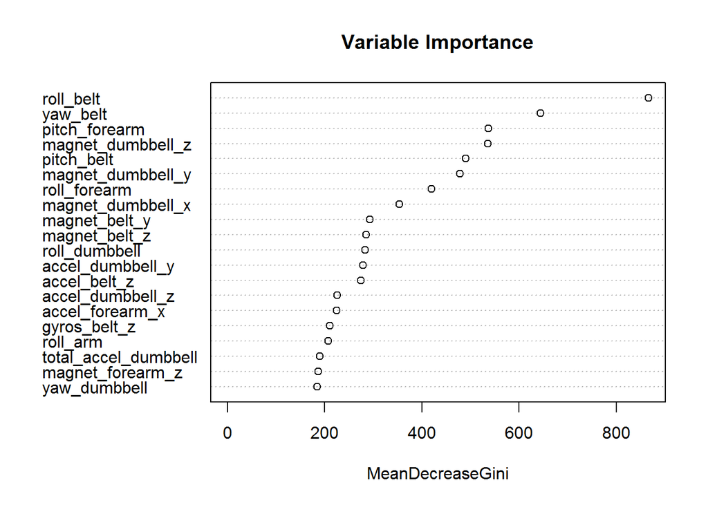

```r
varImpPlot(mod.rf, main="Variable Importance",n.var=20)
```

## Prediction

I used RF model for prediction of classes with test set.

```r
test.predict.rf <- predict(mod.rf, ds.test, type = "class")

pml_write_files = function(x){
  n = length(x)
  for(i in 1:n){
    filename = paste0("problem_id_",i,".txt")
    write.table(x[i],file=filename,quote=FALSE,row.names=FALSE,col.names=FALSE)
  }
}
pml_write_files(test.predict.rf)
```

And I’ve got expected results.